# Process Data Reindeer

Maxime Jan

2022-09-21

# LIBS

```r
# Install if not available !
library(R.matlab)
```

```r
library(ggplot2)
source("RFunction/DataProcessing.R")
```

# Read Input

Read matlab file in data directory

```r
## Old file given
# dataMat<-readMat("../data/matfiles_swa_std_processS/SWA_STD_all.mat")
# names(dataMat)

# dataMat<-readMat("../data/matfiles_swa_std_processS/SWA_STD_episodes_all.mat")
# names(dataMat)
#
# dataMat2<-readMat("../data/matfiles_swa_std_processS/SWA_STD_episodes_allnew.mat")
# names(dataMat2)

#dataMat<-readMat("../data/matfiles_swa_std_processS/SWA_STD_episodes_all_rumwn.mat")
#dataMat<-readMat("../data/matfiles_swa_std_processS/SWA_STD_episodes_newnormalization.mat")

# More recent !

dataMat<-readMat("../data/matfiles_swa_std_processS/SWA_scoring_episodes_BLnorm.mat")
names(dataMat)
```

```
## [1] "SWA.absolute"   "SWA.normalized" "episodes"       "filenames"
## [5] "scoring"
```

From Melanie Furer:

I uploaded a new file “SWA_STD_episodes_all_rumwn.mat” with a new variable “scoring_rumwn”, where I replaced the labels for rumination (4 and t) in a way that now 4 corresponds to “rum-wake” and t to “rum-sleep” based on spindle density criteria. The variable “spindles_all” has the number of spindles detected per 4s-epoch (only for rumination, the rest are NaN), just in case you can use that info too.

```r
# Transform 'wrnwnr' into 'w','r','n'...
Scoring<-apply(dataMat$scoring,1,function(x){
  return(strsplit(x,"")[[1]])
})

# Old scoring containing RUMW and RUMN, keep if you want to reuse it !
ScoringRUMWN<-Scoring
# ScoringRUMWN<-apply(dataMat$scoring.rumwn,1,function(x){
#   return(strsplit(x,"")[[1]])
# })
```

## Filtering old file

eval=F -> these functions are not runned .

Some scoring don’t have 81900 scores (old file, not anymore in the new one)

```r
sapply(Scoring,length)
```

merge good results

```r
idx_good<-which(sapply(Scoring,length) == 81900)
```

Some score have a ’ why ?

```r
Scorematrix<-do.call("cbind",Scoring[idx_good])
colnames(Scorematrix)<-paste("Ind",idx_good,sep="")
dataMat$SWA.absolute<-t(dataMat$SWA.absolute[idx_good,])
colnames(dataMat$SWA.absolute)<-paste("Ind",idx_good,sep="")
dataMat$SWA.normalized<-t(dataMat$SWA.normalized[idx_good,])
colnames(dataMat$SWA.normalized)<-paste("Ind",idx_good,sep="")
table(Scorematrix)
```

## Process new file

```r
Scorematrix<-Scoring
colnames(Scorematrix)<-paste("Ind",1:ncol(Scorematrix),sep="")
dataMat$SWA.absolute<-t(dataMat$SWA.absolute)
colnames(dataMat$SWA.absolute)<-paste("Ind",1:ncol(Scorematrix),sep="")
dataMat$SWA.normalized<-t(dataMat$SWA.normalized)
colnames(dataMat$SWA.normalized)<-paste("Ind",1:ncol(Scorematrix),sep="")
table(Scorematrix)
```

```
## Scorematrix
##      2      4      m      n      r      t      w
##   3831   5823  51722 195763  29331  74454 539976
```

```r
ScorematrixRUMWN<-ScoringRUMWN
colnames(ScorematrixRUMWN)<-paste("Ind",1:ncol(ScorematrixRUMWN),sep="")
table(ScorematrixRUMWN)
```

```
## ScorematrixRUMWN
##      2      4      m      n      r      t      w
##   3831   5823  51722 195763  29331  74454 539976
```

# Quantify scoring

Visualization, mean per 3600 seconds

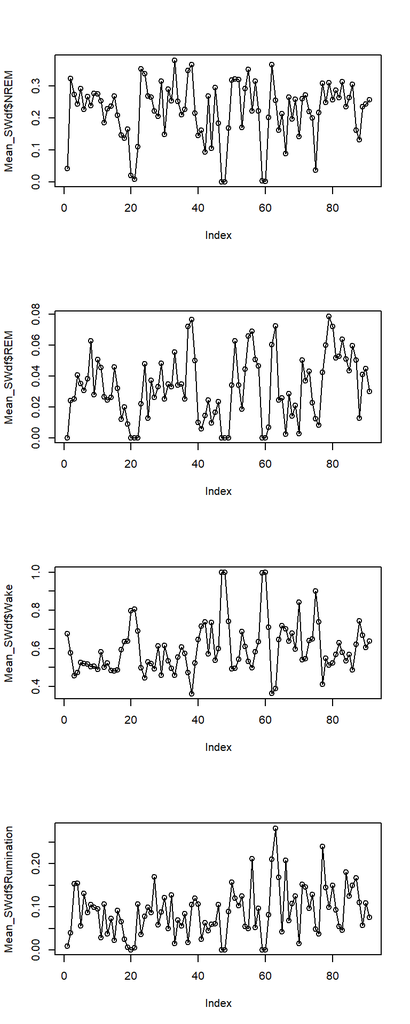

```r
Mean_SWdf<-ReadReindeerScoring(Scorematrix,nepochs=81900, concattimesec = 3600,concat = "mean")
par(mfcol=c(4,1))
plot(Mean_SWdf$NREM);lines(Mean_SWdf$NREM)
plot(Mean_SWdf$REM);lines(Mean_SWdf$REM)
plot(Mean_SWdf$Wake);lines(Mean_SWdf$Wake)
plot(Mean_SWdf$Rumination);lines(Mean_SWdf$Rumination)
```

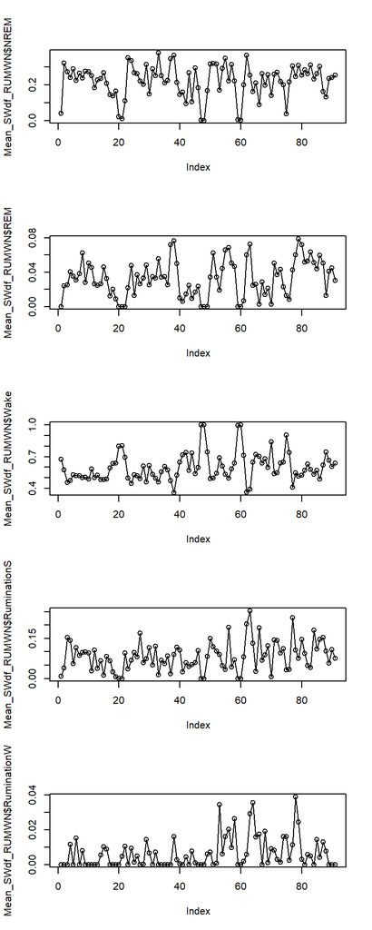

```r
Mean_SWdf_RUMWN<-ReadReindeerScoring(ScorematrixRUMWN,nepochs=81900, concattimesec = 3600,concat = "mean",rumWN = T)
par(mfrow=c(5,1))
plot(Mean_SWdf_RUMWN$NREM);lines(Mean_SWdf_RUMWN$NREM)
plot(Mean_SWdf_RUMWN$REM);lines(Mean_SWdf_RUMWN$REM)
plot(Mean_SWdf_RUMWN$Wake);lines(Mean_SWdf_RUMWN$Wake)
plot(Mean_SWdf_RUMWN$RuminationS);lines(Mean_SWdf_RUMWN$RuminationS)
plot(Mean_SWdf_RUMWN$RuminationW);lines(Mean_SWdf_RUMWN$RuminationW)
```

See data for Ind1 on multiple intervals

```r
aa<-ReadReindeerScoring(Scorematrix[,1,drop=F],nepochs=81900, concattimesec = 4,concat = "mean")

pdf(file="../docs/Reindeer.pdf")
plot(dataMat$SWA.normalized[,1],type="l",xlim=c(1300,1800),ylim=c(-3,8),xaxt="n")
axis(1,seq(0,81900,by=90),labels = round(seq(0,81900,by=90)/900,1))
lines(200*aa$Wake,col="blue")
lines(-1+200*aa$NREM,col="red")
lines(-2+200*aa$REM,col="green")
lines(-3+200*aa$Rumination,col="purple")


plot(dataMat$SWA.normalized[,1],xlim=c(43800,44260),type="l",ylim=c(-3,8),xaxt="n")
axis(1,seq(0,81900,by=90),labels = round(seq(0,81900,by=90)/900,1))

lines(200*aa$Wake,col="blue")
lines(-1+200*aa$NREM,col="red")
lines(-2+200*aa$REM,col="green")
lines(-3+200*aa$Rumination,col="purple")


plot(dataMat$SWA.normalized[,1],xlim=c(81300,81700),type="l",ylim=c(-3,8),xaxt="n")
axis(1,seq(0,81900,by=90),labels = round(seq(0,81900,by=90)/900,1))

lines(200*aa$Wake,col="blue")
lines(-1+200*aa$NREM,col="red")
lines(-2+200*aa$REM,col="green")
lines(-3+200*aa$Rumination,col="purple")


plot(dataMat$SWA.normalized[,1],type="l",ylim=c(-3,8),xaxt="n")
axis(1,seq(0,81900,by=90),labels = round(seq(0,81900,by=90)/900,1))

lines(200*aa$Wake,col="blue")
lines(-1+200*aa$NREM,col="red")
lines(-2+200*aa$REM,col="green")
lines(-3+200*aa$Rumination,col="purple")
dev.off()
```

# Define delta power

Old function to get delta-power as maximum value reach per bout of NREM

black line is a spline, red is an saturating exponential function

```
## [1] "1 1"
```

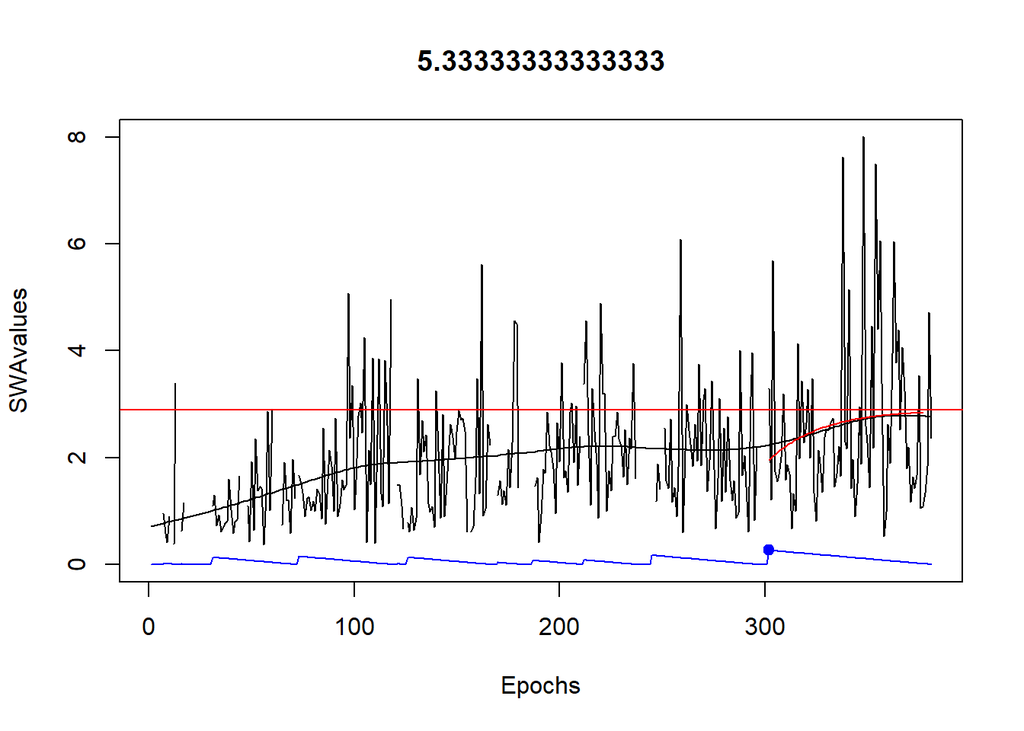

```
## [1] "1 3"
```

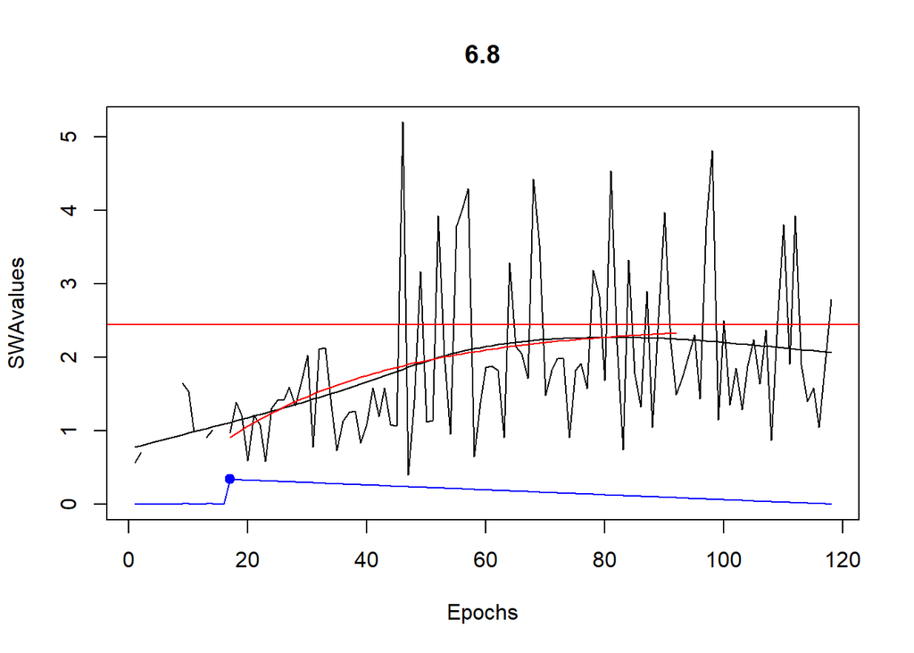

```
## [1] "1 9"
```

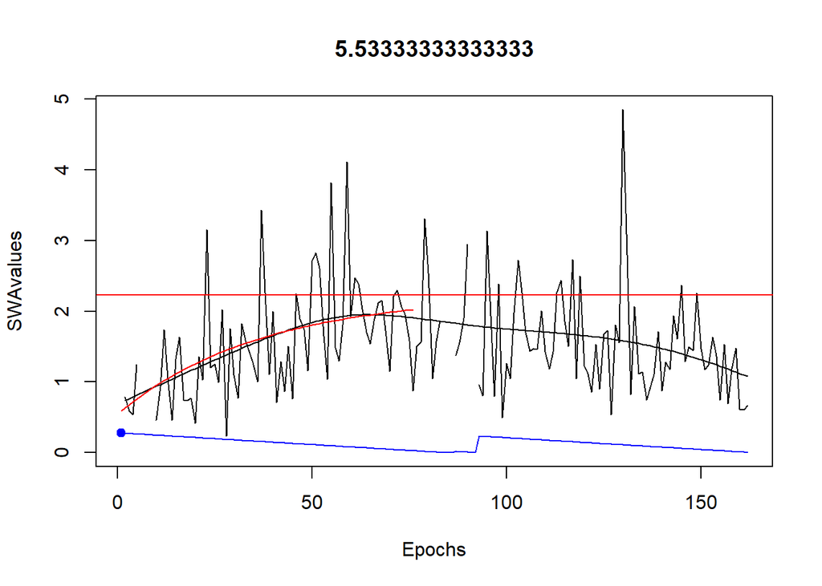

```
## [1] "1 10"
```

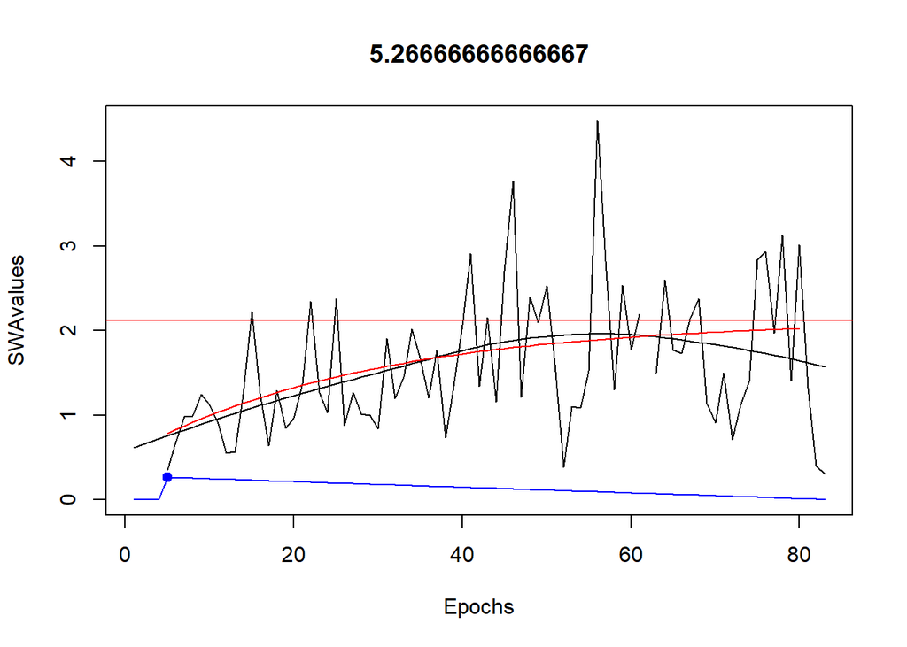

```
## [1] "1 13"
```

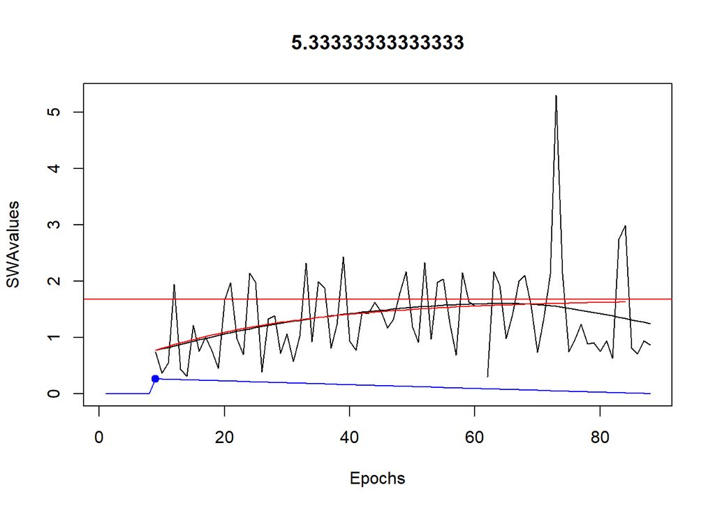

```
## [1] "1 19"
```

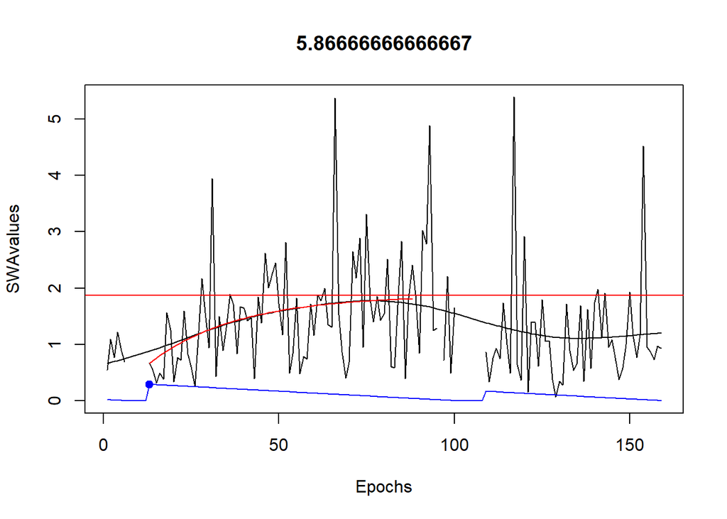

```
## [1] "1 24"
```

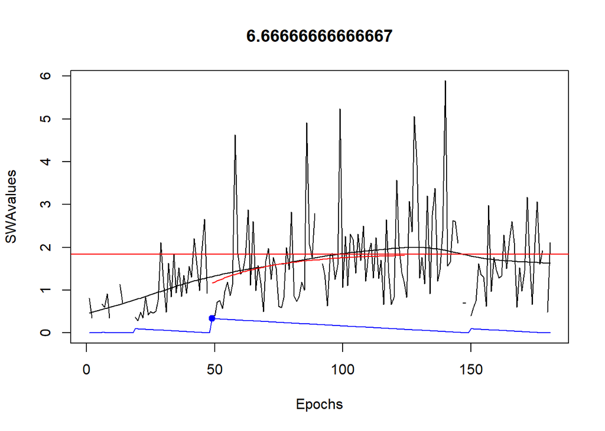

```
## [1] "1 26"
```

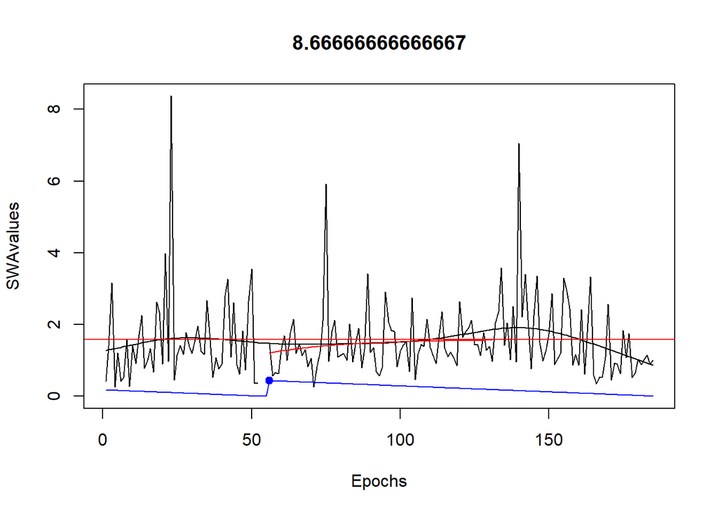

```
## [1] "1 34"
```

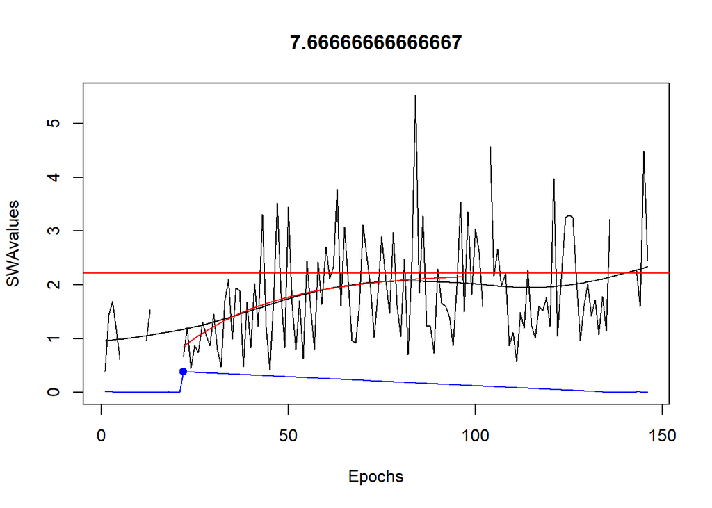

```
## [1] "1 35"
```

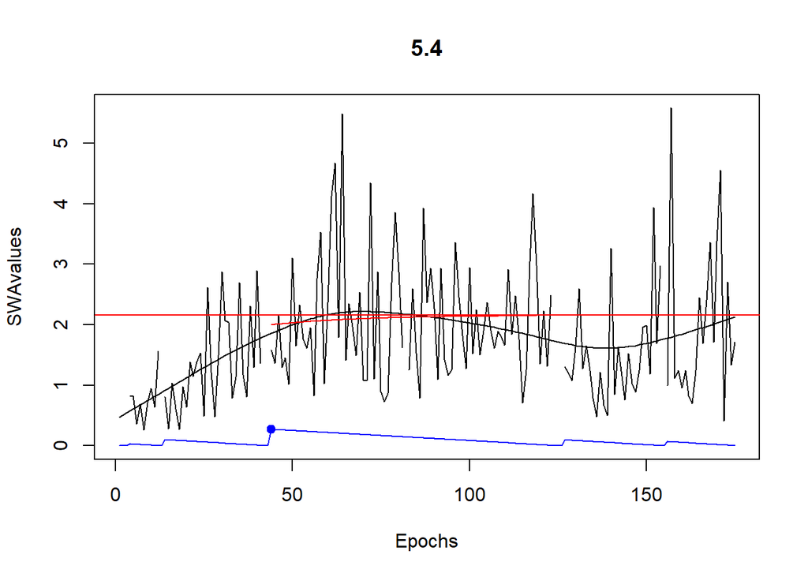

```
## [1] "1 38"
```

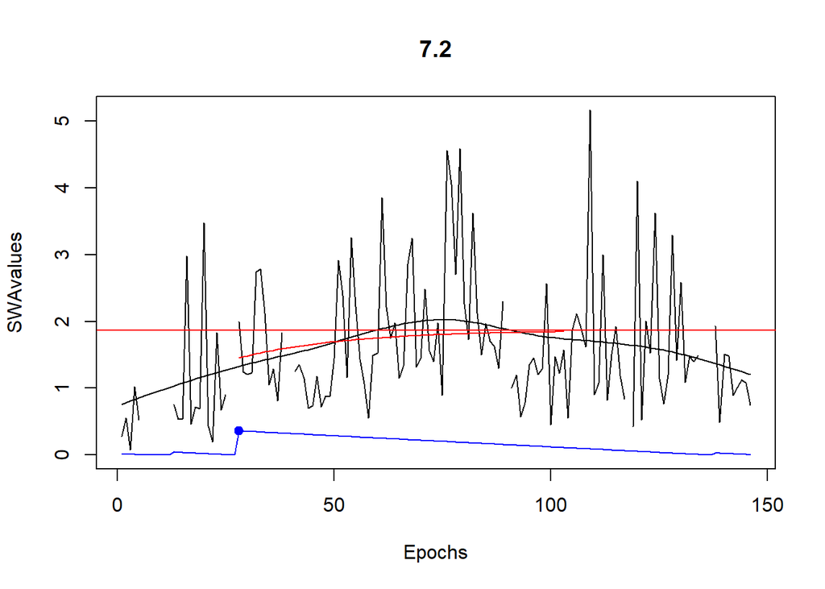

```
## [1] "1 39"
```

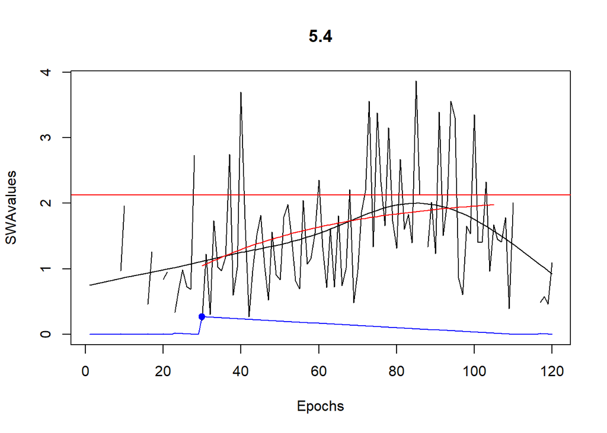

```
## [1] "1 42"
```

[23 more figures not shown]

```r
tt<-GetMaxSWAperBout(deerid = 1,DoPlot = T)
```

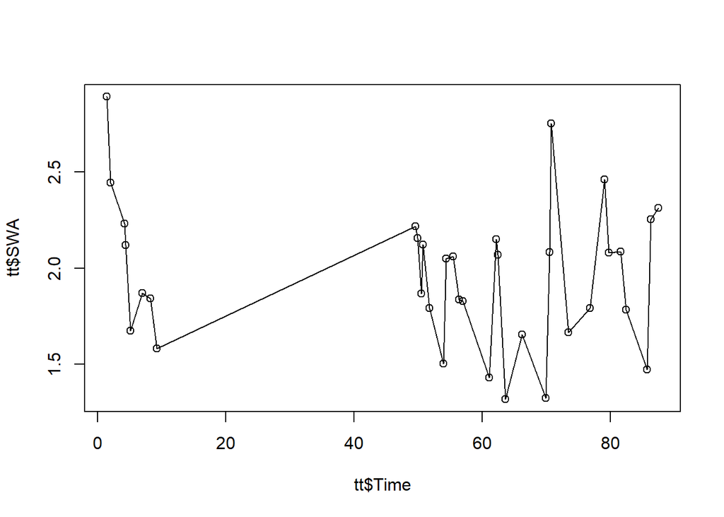

```r
plot(tt$Time,tt$SWA,type="l")
points(tt$Time,tt$SWA)
```

Get mean SWA in a bout of NREM, as continuous NREM for minboutlength_sec seconds

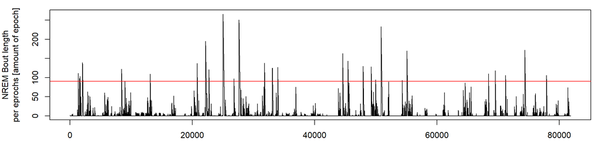

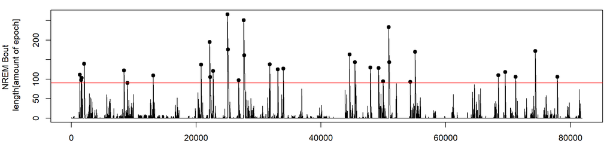

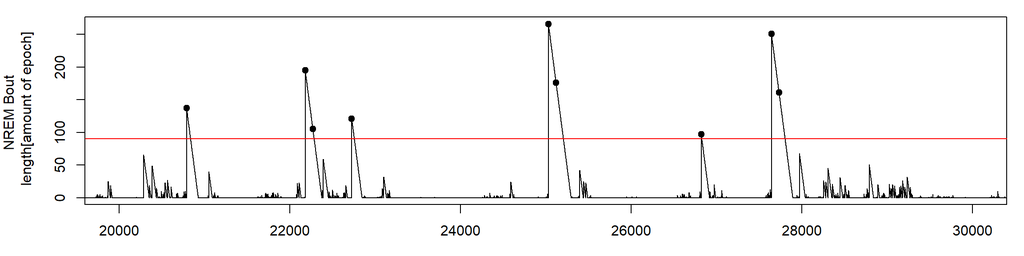

| idx_start | SWA |
| --- | --- |
| 1424 | 1.342191 |
| 1641 | 1.657831 |
| 1747 | 1.999019 |
| 2144 | 1.790520 |
| 8534 | 1.183898 |
| 9083 | 1.175901 |
| 13214 | 1.807905 |
| 20879 | 1.429702 |
| 22269 | 1.036352 |
| 22359 | 1.939094 |

[output cut: 23 more lines]

```r
GetSWA4BoutsOfNREM(SWA=dataMat$SWA.normalized[,3],Scoring=Scorematrix[,3],minboutlength_sec=360,epochlengthsec = 4)
```

# Save data

```r
BoutMinThresh<-30
Timeconcat<-4

dataReindeer<-list(SWdf=list(),DeltaPow=list(),Episodes=list(),FullDeltaPow=list())
for (Ind in colnames(Scorematrix)){
  dataReindeer[["SWdf"]][[Ind]]<-ReadReindeerScoring(Scorematrix[,Ind,drop=F],nepochs=81900, concattimesec = Timeconcat,concat = "mean")

  #dataReindeer[["DeltaPow"]][[Ind]]<-as.data.frame(GetMaxSWAperBout(as.numeric(gsub("Ind","",Ind,))))
  #dataReindeer[["DeltaPow"]][[Ind]]<-as.data.frame(GetSWA4BoutsOfNREM(SWA=dataMat$SWA.absolute[,Ind],Scoring=Scorematrix[,Ind],minboutlength_sec=BoutMinThresh,epochlengthsec = 4))

  # add time
  dataReindeer[["SWdf"]][[Ind]]$Time<-cumsum(rep(Timeconcat,nrow(dataReindeer[["SWdf"]][[Ind]])))/(3600)
  dataReindeer[["FullDeltaPow"]][[Ind]]<-cbind.data.frame(SWA=dataMat$SWA.normalized[,Ind],Time=1:nrow(dataMat$SWA.normalized)*4/3600)

  dataReindeer[["NREMEpisodes"]][[Ind]]<- dataMat$episodes[,,as.numeric(gsub("Ind","",Ind,))]$nremdura

}

dataReindeerRUMWN<-list(SWdf=list(),DeltaPow=list(),Episodes=list(),FullDeltaPow=list())
for (Ind in colnames(ScorematrixRUMWN)){

  dataReindeerRUMWN[["SWdf"]][[Ind]]<-ReadReindeerScoring(ScorematrixRUMWN[,Ind,drop=F],nepochs=81900, concattimesec = Timeconcat,concat = "mean",rumWN = T)

  #dataReindeerRUMWN[["DeltaPow"]][[Ind]]<-as.data.frame(GetMaxSWAperBout(as.numeric(gsub("Ind","",Ind,))))
  #dataReindeer[["DeltaPow"]][[Ind]]<-as.data.frame(GetSWA4BoutsOfNREM(SWA=dataMat$SWA.absolute[,Ind],Scoring=Scorematrix[,Ind],minboutlength_sec=BoutMinThresh,epochlengthsec = 4))

  # add time
  dataReindeerRUMWN[["SWdf"]][[Ind]]$Time<-cumsum(rep(Timeconcat,nrow(dataReindeerRUMWN[["SWdf"]][[Ind]])))/(3600)
  dataReindeerRUMWN[["FullDeltaPow"]][[Ind]]<-cbind.data.frame(SWA=dataMat$SWA.normalized[,Ind],Time=1:nrow(dataMat$SWA.normalized)*4/3600)

  dataReindeerRUMWN[["NREMEpisodes"]][[Ind]]<- dataMat$episodes[,,as.numeric(gsub("Ind","",Ind,))]$nremdura

}
```

```r
save(dataReindeer,dataReindeerRUMWN,file="../data/dataReindeer_processed_BLhnorm.Rdata")
```